# lab2

Lisa McDaniel

9/8/2020

**Reading the Data:**

```r
choco <- read.csv("https://raw.githubusercontent.com/xdaiISU/ds202materials/master/hwlabs/data/choco.csv")
str(choco)
```

```
'data.frame':   2312 obs. of  13 variables:
 $ REF                 : int  2454 2458 2454 797 797 1015 1019 1011 1019 1011 ...
 $ Company             : chr  "5150" "5150" "5150" "A. Morin" ...
 $ Location            : chr  "U.S.A." "U.S.A." "U.S.A." "France" ...
 $ Date                : int  2019 2019 2019 2012 2012 2013 2013 2013 2013 2013 ...
 $ Bean_Origin         : chr  "Madagascar" "Dominican Republic" "Tanzania" "Peru" ...
 $ Specific_Bean_Origin: chr  "Bejofo Estate, batch 1" "Zorzal, batch 1" "Kokoa Kamili, batch 1" "Peru" ...
 $ Cocoa_Percent       : num  76 76 76 63 70 70 63 70 70 70 ...
 $ Ingredients         : chr  "3- B,S,C" "3- B,S,C" "3- B,S,C" "4- B,S,C,L" ...
 $ Characteristics1    : chr  "cocoa" "cocoa" "rich cocoa" "fruity" ...
 $ Characteristics2    : chr  "blackberry" "vegetal" "fatty" "melon" ...
 $ Characteristics3    : chr  "full body" "savory" "bready" "roasty" ...
 $ Characteristics4    : chr  NA NA NA NA ...
 $ Rating              : num  3.75 3.5 3.25 3.75 3.5 4 4 3.75 3.5 3.25 ...
```

**Searching for the Best Chocolates:**

1. How are the ratings distributed? Create both a histogram and a boxplot and describe them. Don’t forget to mention outliers, if there are any.

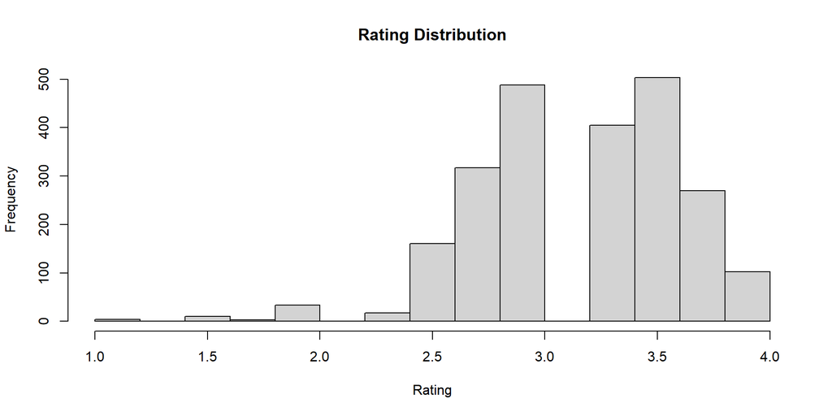

**Rating Histogram** I don’t konw that you can say that the data is left skewed. I think anything less then 2.5 should be considered an outlier.

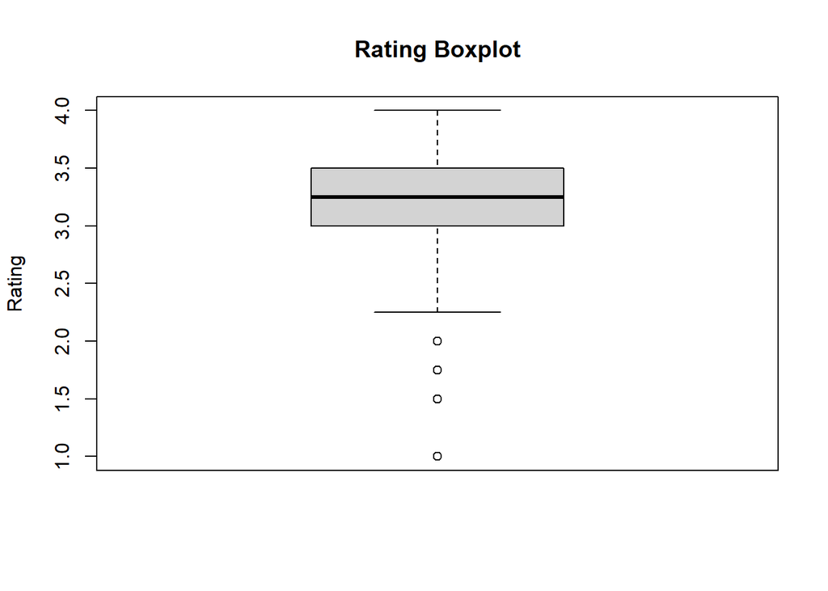

**Rating Boxplot** The median is roughly 3.25, maximum value is 4 and the minimum value is 2.25; confirms that there are 4 outliers; Q3=3.5, Q1=3; IQR=0.5 which indicates that the spread of the data is pretty narrow.

2. How does the number of ratings depend on the year? Draw a bar chart of the number of reports.

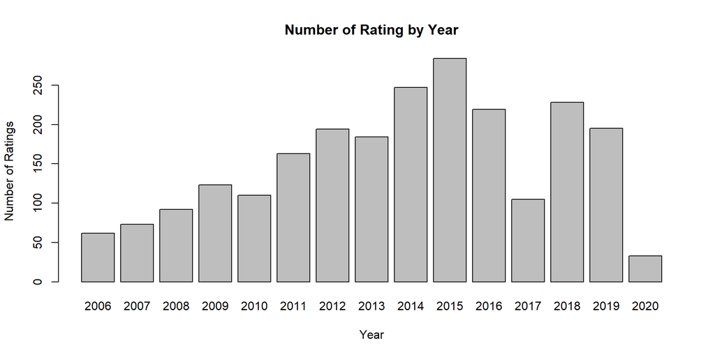

**Observations** It appears that the number of ratings has steadily increased since the project began in 2006, peaking in 2015. The number ratings between 2016 - 2019 (excluding 2017) are similar. I would consider the number of ratings in 2020 as incomplete and would not make any observations for this year.

3. Do ratings depend on the cacao percentage of a chocolate bar? Create both numerical and graphical summaries, and explain.

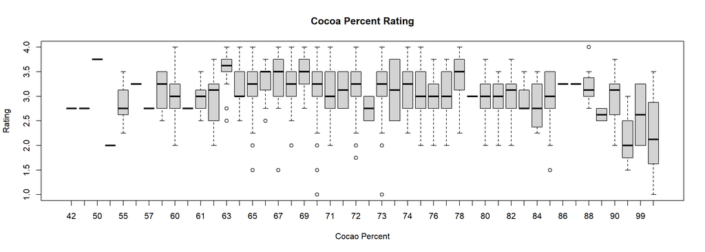

4. How do different characteristics of the chocolate compare? To elaborate, which characteristics tend to be more favorable and which ones are not? Create both numerical and graphical summaries, and explain.

**Top 5 Most Flavorable Characteristics (rating>= 3**

*Charactersitic 1:* There are 1768 records that have a rating >=3. That includes 372 flavors in Characteristic 1; 49 flavors in charactersitc 1 have a rating >=4 including *oily, sweet, delicate* and *strong spice*.

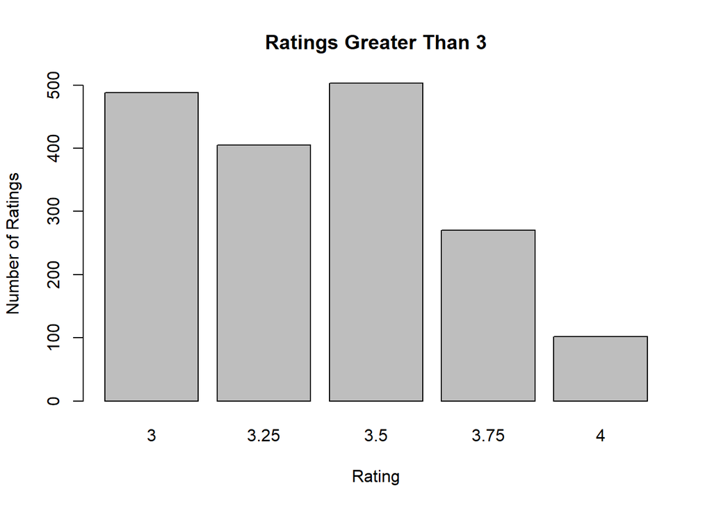

*Charactersitic 3:* Of the 1768 records, that includes 292 flavors in Characteristic ; 47 flavors in charactersitc 3 have a rating >=4 including *carmel, tangerine, brownie* and *smoke*

*Charactersitic 4:* Of the 1768 records, that includes 71 flavors in Characteristic 4; 12 flavors in charactersitc 4 have a rating >=4 including *raspberry, banana, rich* and *cocoa*

**Top 5 Least Flavorable Characteristics (Rating <= 2)**

*Charactersitic 1:* There are 35 flavors in Characteristic 1 that have a rating <=2. Four of these flavors have a rating <=1: *bitter, chalky, this is not chocolate* and *pastey*.

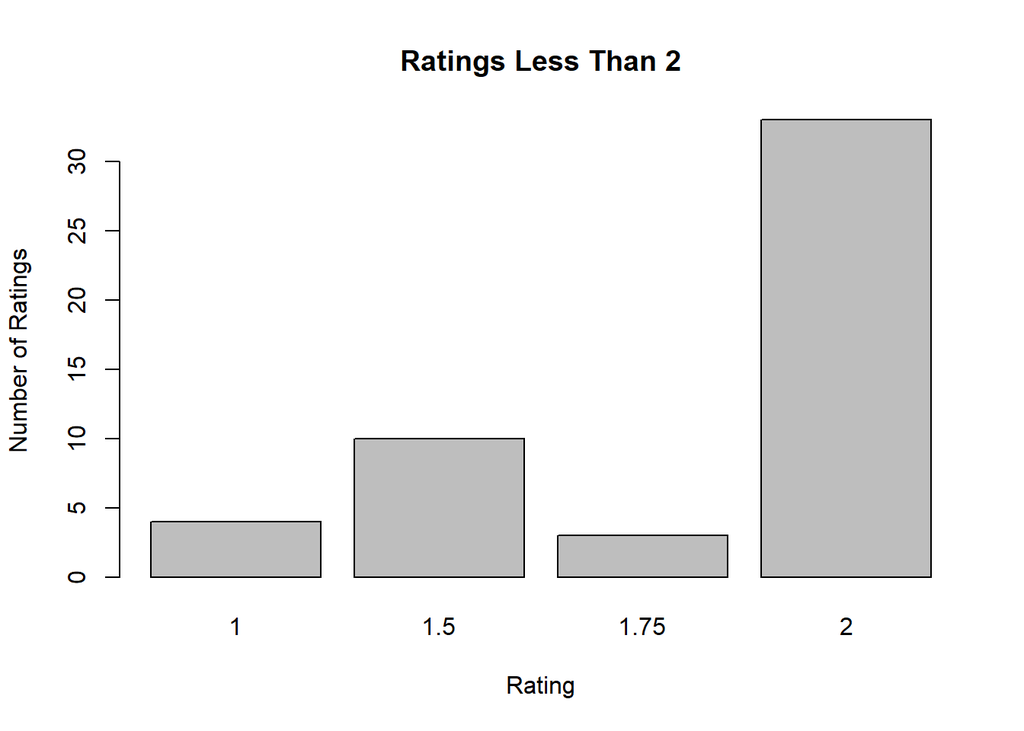

*Charactersitic 2:* There are 39 flavors (1 NA) in Characteristic 2 that have a rating <=2. Three of these flavors have a rating <=1: *cocoa, musty* and *strong off flavor*.

*Charactersitic 3:* There are 23 (1 identified as NA) flavors in Characteristic 3 that have a rating <=2. Only one flavor has a rating <=1: *very bitter*.

*Charactersitic 4:* There 1 flavor in Characteristic 4 that has a rating <=2 and no flavors with a rating <= 1.

5. Brainstorm two analyses you would like to perform with your teammate. Describe in plain language what comparisons are you making. Create suitable numerical and graphical summaries for your analyses. Describe the results.

**Analysis: USA Chocolate**

I got the summary statistics for the dataset and saw that there are 2312 records. I filtered the original data to include only those records where the *Location* was *U.S.A* and stored the 966 records in USAchoch. I further filtered the data to include only those records where the *Bean Origin* was also in the *U.S.A and stored the 28 records in USAbean. I got the summary statistics for USABean and created plots showing the number of ratings per yeary and by cocoa percentage.

Ratings began in 2006 but have not been yearly. Ratings peaked in 2012, 2013 and 2014 and have remained pretty steady over the past few years.

```
      REF         Company            Location              Date
 Min.   :   5   Length:2312        Length:2312        Min.   :2006
 1st Qu.: 741   Class :character   Class :character   1st Qu.:2011
 Median :1351   Mode  :character   Mode  :character   Median :2014
 Mean   :1318                                         Mean   :2014
 3rd Qu.:1912                                         3rd Qu.:2016
 Max.   :2490                                         Max.   :2020
 Bean_Origin        Specific_Bean_Origin Cocoa_Percent    Ingredients
 Length:2312        Length:2312          Min.   : 42.00   Length:2312
 Class :character   Class :character     1st Qu.: 70.00   Class :character
 Mode  :character   Mode  :character     Median : 70.00   Mode  :character
                                         Mean   : 71.65
                                         3rd Qu.: 75.00
                                         Max.   :100.00
 Characteristics1   Characteristics2   Characteristics3   Characteristics4
 Length:2312        Length:2312        Length:2312        Length:2312
 Class :character   Class :character   Class :character   Class :character
 Mode  :character   Mode  :character   Mode  :character   Mode  :character



     Rating
 Min.   :1.000
 1st Qu.:3.000
 Median :3.250
 Mean   :3.184
 3rd Qu.:3.500
 Max.   :4.000
```

```
      REF         Company            Location              Date
 Min.   :  24   Length:28          Length:28          Min.   :2006
 1st Qu.: 719   Class :character   Class :character   1st Qu.:2011
 Median :1048   Mode  :character   Mode  :character   Median :2013
 Mean   :1055                                         Mean   :2013
 3rd Qu.:1371                                         3rd Qu.:2014
 Max.   :2482                                         Max.   :2020
 Bean_Origin        Specific_Bean_Origin Cocoa_Percent   Ingredients
 Length:28          Length:28            Min.   :55.00   Length:28
 Class :character   Class :character     1st Qu.:69.25   Class :character
 Mode  :character   Mode  :character     Median :70.00   Mode  :character
                                         Mean   :69.25
                                         3rd Qu.:72.00
                                         Max.   :85.00
 Characteristics1   Characteristics2   Characteristics3   Characteristics4
 Length:28          Length:28          Length:28          Length:28
 Class :character   Class :character   Class :character   Class :character
 Mode  :character   Mode  :character   Mode  :character   Mode  :character



     Rating
 Min.   :2.000
 1st Qu.:3.000
 Median :3.250
 Mean   :3.196
 3rd Qu.:3.500
 Max.   :3.750
```

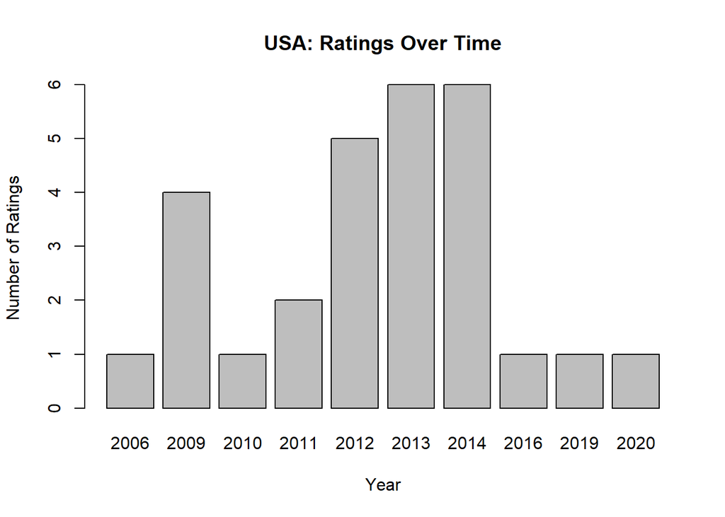

The most commonly rated chocolate has a cocoa percentage of 70%, followed by 72%.

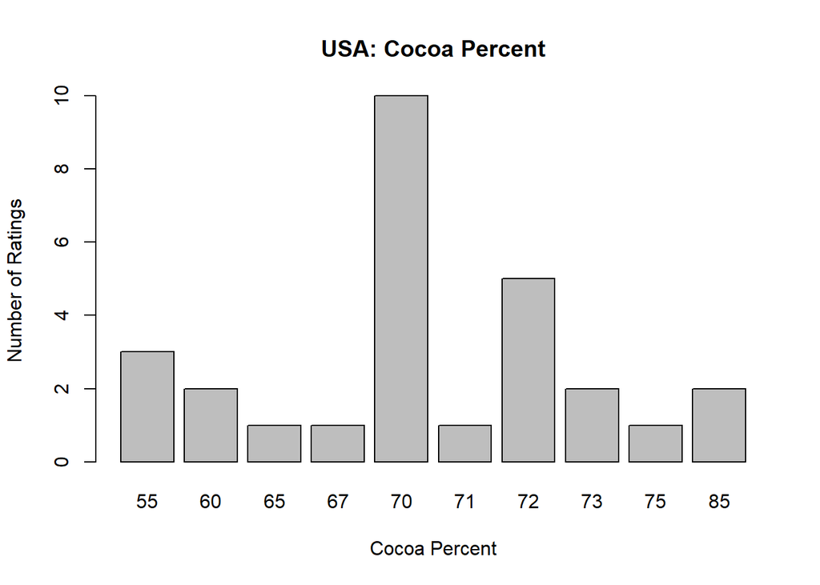

Created box plots to show the ratings per cocoa percentage. Chocolate with 67% and 75% have the most favorable rating of 3.75.

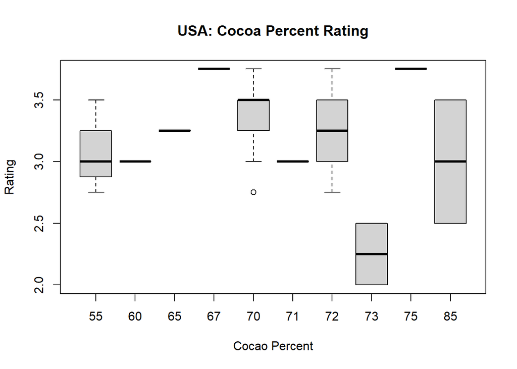